# Revenue Analysis

S. 5

Laurens

May 31, 2025

# Data Overview

```
##  Glimpse of 'Ratio_btn_Act_and_Bud'
```

```
## Rows: 384
## Columns: 4
## $ assembly              <fct> WA, WA, WA, WA, WA, WA, WA, WA, WA, WA, WA, WA, …
## $ revenue_item          <fct> Property Rates, Property Rates, Property Rates, …
## $ year                  <chr> "2017", "2018", "2019", "2020", "2021", "2022", …
## $ Ratio_btn_Act_and_Bud <dbl> NA, 0.00, NA, 9.80, NA, 27.84, 1.20, 1.50, NA, 2…
## # A tibble: 384 × 4
##    assembly revenue_item   year  Ratio_btn_Act_and_Bud
##    <fct>    <fct>          <chr>                 <dbl>
##  1 WA       Property Rates 2017                  NA
##  2 WA       Property Rates 2018                   0
##  3 WA       Property Rates 2019                  NA
##  4 WA       Property Rates 2020                   9.8
##  5 WA       Property Rates 2021                  NA
##  6 WA       Property Rates 2022                  27.8
##  7 WA       Property Rates 2023                   1.2
##  8 WA       Property Rates 2024                   1.5
##  9 WA       Other Rates    2017                  NA
## 10 WA       Other Rates    2018                   2.99
## # ℹ 374 more rows
```

```
##           assembly                     revenue_item     year
##  BOLGATANGA   :64   Fees                     :48    Length:384
##  EAST MAMPRUSI:64   Fines                    :48    Class :character
##  TAMALE       :64   Investment               :48    Mode  :character
##  WA           :64   Land (incl Miscellaneous):48
##  WEST GONJA   :64   Licences                 :48
##  YENDI        :64   Other Rates              :48
##                     (Other)                  :96
##  Ratio_btn_Act_and_Bud
##  Min.   :   0.0000
##  1st Qu.:   0.3375
##  Median :   1.0000
##  Mean   :  30.7162
##  3rd Qu.:   1.6000
##  Max.   :8617.6000
##  NA's   :56
```

```
## [1] Property Rates            Other Rates
## [3] Fees                      Fines
## [5] Licences                  Land (incl Miscellaneous)
## [7] Rent                      Investment
## 8 Levels: Fees Fines Investment Land (incl Miscellaneous) ... Rent
```

```
## [1] "2017" "2018" "2019" "2020" "2021" "2022" "2023" "2024"
```

```
## [1] WA            TAMALE        BOLGATANGA    YENDI         EAST MAMPRUSI
## [6] WEST GONJA
## Levels: BOLGATANGA EAST MAMPRUSI TAMALE WA WEST GONJA YENDI
```

Summary of Ratio Between Actual and Budget

| skim_variable | numeric.mean | numeric.sd | numeric.p0 | numeric.p25 | numeric.p50 | numeric.p75 | numeric.p100 | numeric.hist |
| --- | --- | --- | --- | --- | --- | --- | --- | --- |
| data | 30.72 | 476.59 | 0 | 0.34 | 1 | 1.6 | 8617.6 | ▇▁▁▁▁ |

Skewness and Kurtosis of Ratio Between Actual and Budget

| Skewness | Kurtosis |
| --- | --- |
| 17.92 | 323.24 |

```
## --- Distribution of Observations ---
```

Assembly Distribution

| assembly | n | Proportion |
| --- | --- | --- |
| BOLGATANGA | 64 | 0.167 |
| EAST MAMPRUSI | 64 | 0.167 |
| TAMALE | 64 | 0.167 |
| WA | 64 | 0.167 |
| WEST GONJA | 64 | 0.167 |
| YENDI | 64 | 0.167 |

Revenue Item Distribution

| revenue_item | n | Proportion |
| --- | --- | --- |
| Fees | 48 | 0.125 |
| Fines | 48 | 0.125 |
| Investment | 48 | 0.125 |
| Land (incl Miscellaneous) | 48 | 0.125 |
| Licences | 48 | 0.125 |
| Other Rates | 48 | 0.125 |
| Property Rates | 48 | 0.125 |
| Rent | 48 | 0.125 |

Year Distribution

| year | n | Proportion |
| --- | --- | --- |
| 2017 | 48 | 0.125 |
| 2018 | 48 | 0.125 |
| 2019 | 48 | 0.125 |
| 2020 | 48 | 0.125 |
| 2021 | 48 | 0.125 |
| 2022 | 48 | 0.125 |
| 2023 | 48 | 0.125 |
| 2024 | 48 | 0.125 |

- Observations

The Ratio_btn_Act_and_Bud dataset (384 rows, 4 columns: assembly, revenue_item, year, Ratio_btn_Act_and_Bud) measures the ratio of actual to budgeted revenue across 6 assemblies (WA, Tamale, Bolgatanga, Yendi, East Mamprusi, West Gonja), 8 revenue items (Property Rates, Other Rates, Fees, Fines, Licences, Land (incl Miscellaneous), Rent, Investment), and years 2017–2024.

Assembly Distribution: Each assembly (WA, Tamale, Bolgatanga, Yendi, East Mamprusi, West Gonja) has 64 rows (16.7% proportion), ensuring equal representation.

Revenue Item Distribution: Each item (Property Rates, Other Rates, Fees, Fines, Licences, Land, Rent, Investment) has 48 rows (12.5% proportion).

Year Distribution: Each year (2017–2024) has 48 rows (12.5% proportion).

The Ratio_btn_Act_and_Bud is right-skewed (mean = 30.72, median = 1.0, min = 0, max = 8,617.6, 56 NAs (14.6%)).

standard deviation of 476.59 The range spans 0 to 8,617.6, with quartiles at 0.34 (Q1) and 1.6 (Q3). most ratios clustered near 0–2 and a long tail.

Skewness and Kurtosis: Skewness of 17.92 and kurtosis of 323.24 highlight a heavily skewed, leptokurtic distribution.

A median of 1.0 suggests actual revenue often matches budgeted revenue, but extreme ratios ( 8,617.6) inflate the mean, indicating rare cases of significant overperformance. The high skewness/kurtosis necessitates robust metrics ( median) and others methods.

# Descriptives

Ratio by Assembly

| assembly | Mean | Median | SD | Min | Max | N |
| --- | --- | --- | --- | --- | --- | --- |
| BOLGATANGA | 1.23 | 0.95 | 1.28 | 0 | 6.3 | 64 |
| EAST MAMPRUSI | 1.10 | 1.10 | 0.89 | 0 | 5.0 | 64 |
| TAMALE | 155.11 | 1.00 | 1151.41 | 0 | 8617.6 | 64 |
| WA | 6.64 | 1.00 | 32.30 | 0 | 219.0 | 64 |
| WEST GONJA | 5.11 | 0.95 | 17.92 | 0 | 127.5 | 64 |
| YENDI | 11.86 | 1.30 | 66.77 | 0 | 500.0 | 64 |

Ratio by Revenue Item

| revenue_item | Mean | Median | SD | Min | Max | N |
| --- | --- | --- | --- | --- | --- | --- |
| Fees | 6.15 | 1.10 | 33.23 | 0 | 219.00 | 48 |
| Fines | 234.59 | 0.00 | 1380.00 | 0 | 8617.60 | 48 |
| Investment | 3.01 | 0.00 | 8.31 | 0 | 38.00 | 48 |
| Land (incl Miscellaneous) | 5.69 | 1.13 | 19.98 | 0 | 127.50 | 48 |
| Licences | 1.19 | 1.00 | 0.75 | 0 | 4.50 | 48 |
| Other Rates | 1.82 | 1.10 | 3.39 | 0 | 20.20 | 48 |
| Property Rates | 2.21 | 1.10 | 4.74 | 0 | 27.84 | 48 |
| Rent | 2.18 | 1.30 | 4.27 | 0 | 28.20 | 48 |

```
## Group-wise Summaries: Year
```

Ratio by Year

| year | Mean | Median | SD | Min | Max | N |
| --- | --- | --- | --- | --- | --- | --- |
| 2017 | 0.96 | 0.6 | 1.34 | 0 | 4.00 | 48 |
| 2018 | 1.33 | 0.9 | 1.50 | 0 | 5.40 | 48 |
| 2019 | 12.46 | 1.0 | 76.12 | 0 | 500.00 | 48 |
| 2020 | 8.56 | 1.1 | 33.56 | 0 | 219.00 | 48 |
| 2021 | 203.29 | 1.1 | 1313.74 | 0 | 8617.60 | 48 |
| 2022 | 1.78 | 1.1 | 4.05 | 0 | 27.84 | 48 |
| 2023 | 1.57 | 0.9 | 2.61 | 0 | 12.24 | 48 |
| 2024 | 4.01 | 1.2 | 18.28 | 0 | 127.50 | 48 |

Ratio by Assembly and Revenue Item

| assembly | revenue_item | count | mean_ratio | median_ratio | sd_ratio | min_ratio | max_ratio |
| --- | --- | --- | --- | --- | --- | --- | --- |
| TAMALE | Fines | 8 | 1233.20 | 2.10 | 3256.21 | 1.10 | 8617.60 |
| YENDI | Fines | 8 | 72.24 | 0.00 | 188.63 | 0.00 | 500.00 |
| WA | Fees | 8 | 32.05 | 1.00 | 82.44 | 0.00 | 219.00 |
| WEST GONJA | Land (incl Miscellaneous) | 8 | 25.93 | 5.00 | 46.96 | 0.00 | 127.50 |
| YENDI | Investment | 8 | 10.89 | 0.80 | 16.67 | 0.00 | 38.00 |
| WA | Property Rates | 8 | 8.07 | 1.50 | 11.72 | 0.00 | 27.84 |
| WEST GONJA | Rent | 8 | 6.39 | 1.68 | 9.92 | 0.24 | 28.20 |
| YENDI | Other Rates | 8 | 4.43 | 1.20 | 7.24 | 0.00 | 20.20 |
| WEST GONJA | Investment | 8 | 3.80 | 1.60 | 4.72 | 0.00 | 12.24 |
| BOLGATANGA | Land (incl Miscellaneous) | 8 | 2.76 | 2.25 | 2.24 | 0.50 | 6.30 |
| TAMALE | Property Rates | 8 | 2.60 | 1.10 | 4.19 | 0.80 | 12.10 |
| WEST GONJA | Other Rates | 8 | 2.22 | 1.74 | 1.59 | 0.60 | 4.25 |
| WA | Land (incl Miscellaneous) | 8 | 2.00 | 1.13 | 3.13 | 0.00 | 9.00 |
| BOLGATANGA | Property Rates | 8 | 2.00 | 1.70 | 1.16 | 1.00 | 4.20 |
| EAST MAMPRUSI | Other Rates | 8 | 1.80 | 1.30 | 1.42 | 1.10 | 5.00 |
| WA | Other Rates | 8 | 1.78 | 2.00 | 1.90 | 0.00 | 5.00 |
| YENDI | Rent | 8 | 1.69 | 1.60 | 0.52 | 0.90 | 2.40 |
| TAMALE | Rent | 8 | 1.68 | 1.50 | 1.12 | 0.00 | 3.10 |
| YENDI | Licences | 8 | 1.64 | 1.30 | 1.33 | 0.70 | 4.50 |
| EAST MAMPRUSI | Rent | 8 | 1.60 | 1.20 | 1.15 | 0.70 | 4.00 |
| WEST GONJA | Licences | 8 | 1.59 | 1.10 | 1.00 | 0.74 | 3.60 |
| EAST MAMPRUSI | Land (incl Miscellaneous) | 8 | 1.53 | 1.50 | 0.53 | 1.00 | 2.20 |
| YENDI | Fees | 8 | 1.34 | 1.40 | 0.26 | 0.80 | 1.60 |
| YENDI | Property Rates | 8 | 1.31 | 1.10 | 1.15 | 0.00 | 3.70 |
| YENDI | Land (incl Miscellaneous) | 8 | 1.30 | 1.00 | 1.11 | 0.30 | 3.40 |
| BOLGATANGA | Fines | 8 | 1.16 | 0.90 | 0.93 | 0.20 | 3.30 |
| TAMALE | Fees | 8 | 1.16 | 1.10 | 0.24 | 0.90 | 1.60 |
| EAST MAMPRUSI | Fees | 8 | 1.10 | 1.10 | 0.16 | 0.90 | 1.40 |
| BOLGATANGA | Fees | 8 | 1.06 | 1.05 | 0.18 | 0.70 | 1.30 |
| EAST MAMPRUSI | Licences | 8 | 1.03 | 1.10 | 0.21 | 0.60 | 1.20 |
| TAMALE | Land (incl Miscellaneous) | 8 | 1.03 | 1.10 | 0.44 | 0.10 | 1.40 |
| TAMALE | Licences | 8 | 1.03 | 1.00 | 0.08 | 1.00 | 1.20 |
| BOLGATANGA | Rent | 8 | 1.02 | 0.85 | 0.51 | 0.30 | 1.90 |
| EAST MAMPRUSI | Property Rates | 8 | 0.96 | 1.00 | 0.57 | 0.00 | 1.90 |
| WA | Licences | 8 | 0.95 | 1.00 | 0.48 | 0.00 | 1.62 |
| BOLGATANGA | Licences | 8 | 0.94 | 0.90 | 0.41 | 0.10 | 1.40 |
| WEST GONJA | Fees | 8 | 0.92 | 1.03 | 0.33 | 0.40 | 1.30 |
| WA | Rent | 8 | 0.84 | 0.93 | 0.61 | 0.15 | 2.00 |
| EAST MAMPRUSI | Investment | 8 | 0.81 | 0.90 | 0.83 | 0.00 | 2.00 |
| WA | Fines | 8 | 0.57 | 0.00 | 0.99 | 0.00 | 1.71 |
| TAMALE | Other Rates | 8 | 0.19 | 0.00 | 0.49 | 0.00 | 1.30 |
| BOLGATANGA | Investment | 8 | 0.00 | 0.00 | 0.00 | 0.00 | 0.00 |
| BOLGATANGA | Other Rates | 8 | 0.00 | 0.00 | 0.00 | 0.00 | 0.00 |
| EAST MAMPRUSI | Fines | 8 | 0.00 | 0.00 | 0.00 | 0.00 | 0.00 |
| TAMALE | Investment | 8 | 0.00 | 0.00 | 0.00 | 0.00 | 0.00 |
| WA | Investment | 8 | 0.00 | 0.00 | 0.00 | 0.00 | 0.00 |
| WEST GONJA | Fines | 8 | 0.00 | 0.00 | 0.00 | 0.00 | 0.00 |
| WEST GONJA | Property Rates | 8 | 0.00 | 0.00 | 0.00 | 0.00 | 0.00 |

Ratio by Year and Revenue Item

| revenue_item | year | count | mean_ratio | median_ratio | sd_ratio | min_ratio | max_ratio |
| --- | --- | --- | --- | --- | --- | --- | --- |
| Fines | 2021 | 6 | 1723.94 | 1.00 | 3853.67 | 0.00 | 8617.60 |
| Fines | 2019 | 6 | 100.46 | 0.90 | 223.35 | 0.00 | 500.00 |
| Fees | 2020 | 6 | 37.52 | 1.30 | 88.91 | 0.90 | 219.00 |
| Land (incl Miscellaneous) | 2024 | 6 | 22.29 | 1.52 | 51.55 | 0.10 | 127.50 |
| Investment | 2020 | 6 | 9.55 | 0.10 | 18.97 | 0.00 | 38.00 |
| Investment | 2021 | 6 | 8.62 | 1.25 | 15.60 | 0.00 | 32.00 |
| Land (incl Miscellaneous) | 2020 | 6 | 8.50 | 1.65 | 15.68 | 0.30 | 40.20 |
| Rent | 2021 | 6 | 6.10 | 1.75 | 10.84 | 1.00 | 28.20 |
| Property Rates | 2022 | 6 | 5.72 | 1.20 | 10.89 | 0.00 | 27.84 |
| Other Rates | 2020 | 6 | 4.86 | 1.10 | 8.62 | 0.00 | 20.20 |
| Land (incl Miscellaneous) | 2017 | 6 | 4.00 | 4.00 | NA | 4.00 | 4.00 |
| Land (incl Miscellaneous) | 2021 | 6 | 3.67 | 3.15 | 3.30 | 0.60 | 9.00 |
| Property Rates | 2023 | 6 | 2.92 | 0.60 | 4.78 | 0.00 | 12.10 |
| Rent | 2020 | 6 | 2.42 | 1.45 | 2.03 | 0.80 | 5.80 |
| Investment | 2023 | 6 | 2.37 | 0.00 | 4.90 | 0.00 | 12.24 |
| Property Rates | 2020 | 6 | 2.30 | 1.10 | 3.70 | 0.00 | 9.80 |
| Other Rates | 2021 | 6 | 2.26 | 1.10 | 2.16 | 0.00 | 5.00 |
| Land (incl Miscellaneous) | 2023 | 6 | 2.19 | 1.25 | 2.05 | 0.50 | 5.82 |
| Licences | 2018 | 6 | 2.02 | 1.10 | 1.60 | 0.90 | 4.50 |
| Other Rates | 2024 | 6 | 1.99 | 0.80 | 2.61 | 0.00 | 6.10 |
| Rent | 2024 | 6 | 1.99 | 1.35 | 2.25 | 0.00 | 6.40 |
| Land (incl Miscellaneous) | 2018 | 6 | 1.59 | 1.36 | 0.97 | 0.60 | 3.40 |
| Rent | 2022 | 6 | 1.54 | 1.54 | 0.95 | 0.37 | 3.10 |
| Fines | 2018 | 6 | 1.52 | 0.55 | 2.02 | 0.00 | 4.70 |
| Investment | 2024 | 6 | 1.50 | 0.00 | 3.04 | 0.00 | 7.59 |
| Other Rates | 2018 | 6 | 1.45 | 0.35 | 2.09 | 0.00 | 5.00 |
| Property Rates | 2018 | 6 | 1.37 | 1.30 | 1.41 | 0.00 | 3.70 |
| Rent | 2023 | 6 | 1.34 | 1.25 | 0.73 | 0.46 | 2.50 |
| Rent | 2017 | 6 | 1.30 | 1.30 | NA | 1.30 | 1.30 |
| Investment | 2022 | 6 | 1.28 | 0.00 | 2.17 | 0.00 | 5.00 |
| Other Rates | 2022 | 6 | 1.27 | 1.30 | 1.18 | 0.00 | 3.18 |
| Licences | 2022 | 6 | 1.27 | 1.10 | 0.39 | 0.90 | 1.89 |
| Licences | 2024 | 6 | 1.24 | 1.20 | 0.28 | 0.94 | 1.70 |
| Fees | 2022 | 6 | 1.22 | 1.06 | 0.30 | 1.00 | 1.68 |
| Fees | 2019 | 6 | 1.17 | 1.20 | 0.15 | 1.00 | 1.30 |
| Fines | 2023 | 6 | 1.17 | 0.00 | 2.49 | 0.00 | 6.20 |
| Land (incl Miscellaneous) | 2022 | 6 | 1.16 | 1.05 | 0.69 | 0.35 | 2.41 |
| Fees | 2024 | 6 | 1.14 | 1.15 | 0.37 | 0.71 | 1.60 |
| Property Rates | 2024 | 6 | 1.12 | 1.20 | 0.57 | 0.00 | 1.60 |
| Other Rates | 2019 | 6 | 1.10 | 1.20 | 0.72 | 0.00 | 2.00 |
| Property Rates | 2017 | 6 | 1.10 | 1.10 | NA | 1.10 | 1.10 |
| Rent | 2019 | 6 | 1.07 | 0.85 | 0.62 | 0.70 | 2.30 |
| Licences | 2021 | 6 | 1.05 | 0.95 | 0.68 | 0.00 | 1.90 |
| Licences | 2020 | 6 | 1.03 | 1.00 | 0.15 | 0.90 | 1.30 |
| Property Rates | 2021 | 6 | 1.02 | 1.00 | 0.69 | 0.00 | 1.90 |
| Fees | 2023 | 6 | 1.01 | 0.95 | 0.25 | 0.69 | 1.40 |
| Fees | 2017 | 6 | 1.00 | 1.00 | NA | 1.00 | 1.00 |
| Fees | 2021 | 6 | 0.98 | 1.15 | 0.50 | 0.00 | 1.30 |
| Licences | 2019 | 6 | 0.97 | 1.00 | 0.29 | 0.60 | 1.40 |
| Licences | 2023 | 6 | 0.93 | 0.95 | 0.19 | 0.70 | 1.16 |
| Rent | 2018 | 6 | 0.93 | 0.54 | 0.97 | 0.15 | 2.65 |
| Investment | 2018 | 6 | 0.90 | 0.00 | 2.20 | 0.00 | 5.40 |
| Fees | 2018 | 6 | 0.88 | 0.94 | 0.30 | 0.40 | 1.20 |
| Fines | 2024 | 6 | 0.78 | 0.45 | 0.94 | 0.00 | 2.10 |
| Property Rates | 2019 | 6 | 0.74 | 0.90 | 0.42 | 0.00 | 1.00 |
| Land (incl Miscellaneous) | 2019 | 6 | 0.72 | 0.70 | 0.70 | 0.00 | 1.50 |
| Fines | 2020 | 6 | 0.70 | 0.00 | 0.99 | 0.00 | 2.10 |
| Other Rates | 2023 | 6 | 0.59 | 0.30 | 0.74 | 0.00 | 1.74 |
| Fines | 2022 | 6 | 0.52 | 0.00 | 0.83 | 0.00 | 1.90 |
| Fines | 2017 | 6 | 0.20 | 0.20 | NA | 0.20 | 0.20 |
| Investment | 2019 | 6 | 0.20 | 0.00 | 0.40 | 0.00 | 0.80 |
| Licences | 2017 | 6 | 0.10 | 0.10 | NA | 0.10 | 0.10 |
| Investment | 2017 | 6 | 0.00 | 0.00 | NA | 0.00 | 0.00 |
| Other Rates | 2017 | 6 | 0.00 | 0.00 | NA | 0.00 | 0.00 |

Ratio by Assembly and Year

| assembly | year | count | mean_ratio | median_ratio | sd_ratio | min_ratio | max_ratio |
| --- | --- | --- | --- | --- | --- | --- | --- |
| TAMALE | 2021 | 8 | 1077.98 | 1.20 | 3046.47 | 0.00 | 8617.60 |
| YENDI | 2019 | 8 | 63.42 | 1.00 | 176.40 | 0.30 | 500.00 |
| WA | 2020 | 8 | 39.02 | 1.70 | 88.24 | 0.90 | 219.00 |
| WEST GONJA | 2024 | 8 | 18.43 | 2.63 | 44.17 | 0.00 | 127.50 |
| YENDI | 2020 | 8 | 8.03 | 1.45 | 13.86 | 0.00 | 38.00 |
| WEST GONJA | 2020 | 8 | 6.11 | 0.75 | 13.90 | 0.00 | 40.20 |
| WA | 2022 | 8 | 5.32 | 1.00 | 11.05 | 0.06 | 27.84 |
| WEST GONJA | 2021 | 8 | 5.26 | 1.75 | 9.44 | 0.00 | 28.20 |
| YENDI | 2021 | 8 | 5.12 | 1.20 | 10.87 | 0.60 | 32.00 |
| WA | 2021 | 8 | 3.20 | 2.00 | 3.83 | 0.00 | 9.00 |
| TAMALE | 2023 | 8 | 2.96 | 1.00 | 4.20 | 0.00 | 12.10 |
| WEST GONJA | 2023 | 8 | 2.86 | 1.21 | 4.23 | 0.00 | 12.24 |
| YENDI | 2018 | 8 | 2.77 | 2.65 | 2.04 | 0.00 | 5.40 |
| BOLGATANGA | 2021 | 8 | 1.93 | 1.35 | 1.60 | 0.80 | 5.10 |
| BOLGATANGA | 2020 | 8 | 1.92 | 1.05 | 2.16 | 0.80 | 6.30 |
| WEST GONJA | 2022 | 8 | 1.87 | 1.69 | 1.68 | 0.00 | 5.00 |
| YENDI | 2024 | 8 | 1.74 | 1.50 | 1.91 | 0.00 | 6.10 |
| EAST MAMPRUSI | 2018 | 8 | 1.46 | 1.15 | 1.59 | 0.00 | 5.00 |
| EAST MAMPRUSI | 2020 | 8 | 1.31 | 1.10 | 1.31 | 0.00 | 4.00 |
| BOLGATANGA | 2018 | 8 | 1.30 | 0.80 | 1.39 | 0.00 | 3.40 |
| TAMALE | 2022 | 8 | 1.30 | 1.15 | 0.90 | 0.00 | 3.10 |
| EAST MAMPRUSI | 2024 | 8 | 1.25 | 1.20 | 0.61 | 0.00 | 2.20 |
| EAST MAMPRUSI | 2022 | 8 | 1.10 | 1.10 | 0.54 | 0.00 | 1.90 |
| BOLGATANGA | 2019 | 8 | 1.07 | 1.05 | 0.26 | 0.70 | 1.40 |
| BOLGATANGA | 2023 | 8 | 1.06 | 0.85 | 1.34 | 0.00 | 4.20 |
| YENDI | 2022 | 8 | 1.04 | 1.25 | 0.71 | 0.00 | 1.80 |
| WA | 2019 | 8 | 1.00 | 1.00 | 0.71 | 0.00 | 2.00 |
| TAMALE | 2018 | 8 | 0.98 | 1.05 | 0.83 | 0.00 | 2.65 |
| BOLGATANGA | 2024 | 8 | 0.98 | 1.00 | 0.69 | 0.00 | 1.90 |
| EAST MAMPRUSI | 2023 | 8 | 0.98 | 1.05 | 0.70 | 0.00 | 2.00 |
| BOLGATANGA | 2017 | 8 | 0.96 | 0.60 | 1.34 | 0.00 | 4.00 |
| BOLGATANGA | 2022 | 8 | 0.96 | 0.80 | 1.03 | 0.00 | 3.30 |
| TAMALE | 2020 | 8 | 0.92 | 1.05 | 0.68 | 0.00 | 2.10 |
| YENDI | 2023 | 8 | 0.88 | 0.65 | 1.14 | 0.00 | 3.40 |
| WA | 2024 | 8 | 0.87 | 0.94 | 0.62 | 0.00 | 1.71 |
| EAST MAMPRUSI | 2021 | 8 | 0.86 | 1.00 | 0.35 | 0.00 | 1.10 |
| TAMALE | 2019 | 8 | 0.85 | 0.95 | 0.57 | 0.00 | 1.40 |
| WA | 2018 | 8 | 0.78 | 0.52 | 1.02 | 0.00 | 2.99 |
| TAMALE | 2024 | 8 | 0.78 | 0.65 | 0.85 | 0.00 | 2.10 |
| EAST MAMPRUSI | 2019 | 8 | 0.76 | 0.85 | 0.55 | 0.00 | 1.50 |
| WEST GONJA | 2018 | 8 | 0.69 | 0.32 | 1.21 | 0.00 | 3.60 |
| WA | 2023 | 8 | 0.65 | 0.68 | 0.62 | 0.00 | 1.51 |
| WEST GONJA | 2019 | 8 | 0.51 | 0.45 | 0.55 | 0.00 | 1.10 |
| EAST MAMPRUSI | 2017 | 8 | NaN | NA | NA | Inf | -Inf |
| TAMALE | 2017 | 8 | NaN | NA | NA | Inf | -Inf |
| WA | 2017 | 8 | NaN | NA | NA | Inf | -Inf |
| WEST GONJA | 2017 | 8 | NaN | NA | NA | Inf | -Inf |
| YENDI | 2017 | 8 | NaN | NA | NA | Inf | -Inf |

```
## $Assembly_Stats
##
##
## |assembly      | mean_ratio| median_ratio| over_performance_pct| extreme_cases| consistency|
## |:-------------|----------:|------------:|--------------------:|-------------:|-----------:|
## |TAMALE        |     155.11|         1.00|                48.21|             2|       -6.42|
## |YENDI         |      11.86|         1.30|                58.93|             4|       -4.63|
## |WA            |       6.64|         1.00|                41.30|             2|       -3.87|
## |WEST GONJA    |       5.11|         0.95|                48.21|             4|       -2.51|
## |BOLGATANGA    |       1.23|         0.95|                43.10|             0|       -0.04|
## |EAST MAMPRUSI |       1.10|         1.10|                53.57|             0|        0.19|
##
## $Revenue_Item_Stats
##
##
## |revenue_item              | mean_ratio| zero_count| max_ratio| min_ratio|
## |:-------------------------|----------:|----------:|---------:|---------:|
## |Fines                     |     234.59|         20|   8617.60|      0.20|
## |Fees                      |       6.15|          1|    219.00|      0.40|
## |Land (incl Miscellaneous) |       5.69|          2|    127.50|      0.10|
## |Investment                |       3.01|         23|     38.00|      0.20|
## |Property Rates            |       2.21|         10|     27.84|      0.70|
## |Rent                      |       2.18|          1|     28.20|      0.15|
## |Other Rates               |       1.82|         14|     20.20|      0.06|
## |Licences                  |       1.19|          1|      4.50|      0.10|
##
## $Yearly_Stats
##
##
## | year| median_ratio| over_target_pct| gini|
## |----:|------------:|---------------:|----:|
## | 2017|          0.6|           37.50| 0.62|
## | 2018|          0.9|           45.83| 0.58|
## | 2019|          1.0|           34.88| 0.93|
## | 2020|          1.1|           54.55| 0.86|
## | 2021|          1.1|           58.14| 0.97|
## | 2022|          1.1|           54.35| 0.60|
## | 2023|          0.9|           37.50| 0.65|
## | 2024|          1.2|           60.42| 0.82|
```

Assembly Summary: Tamale has the highest mean ratio (155.11) but a median of 1.00, with extreme variability (SD = 1151.41, max = 8,617.6). Yendi (mean = 11.86, median = 1.30) and WA (6.64, 1.00) follow, while Bolgatanga (1.23, 0.95) and East Mamprusi (1.10, 1.10) are lowest. Consistency is negative for most (Tamale -6.42), except East Mamprusi (+0.19), due to high SDs relative to means.

Assembly-Item Pairwise: Tamale’s Fines lead (mean = 1,233.20, max = 8,617.6), followed by Yendi’s Fines (72.24, max = 500). WA’s Fees (32.05, max = 219) and West Gonja’s Land (25.93, max = 127.5) are strong performance. Bolgatanga and East Mamprusi show low means ( 0.00 for Investment/Other Rates).

Tamale’s high mean is outlier-driven ( Fines in 2021), while medians (~0.95–1.30) indicate most assemblies achieve actual to budgeted revenue. East Mamprusi’s consistency suggests stable but low performance. Over-performance is common (41–59%), but extreme cases in Tamale/Yendi/WA require validation if you think it is necessary.

Comparison: Tamale’s leadership aligns with diff_btw_Act_and_Bud (mean = 56,921, median = 8,543) and contribution_to_rev (median = 9.95%). East Mamprusi’s low ratios mirror its weak diff_btw_Act_and_Bud (mean = 3,052) and contribution_to_rev (median = 6.35%).

Revenue Items Show Significant Disparities:

Item Summary: Fines have an extreme mean (234.59, max = 8,617.6) but a median (0.00), with 20 zeros (42%). Fees (6.15, median = 1.10, max = 219) and Land (5.69, 1.13, max = 127.5) follow, while Licences (1.19, 1.00) are lowest. Investment has 23 zeros (48%), with a mean of 3.01.

Performance Metrics: Fines lead in mean ratio (234.59), but high zero counts (20) indicate inconsistency. Land/Fees show fewer zeros (1–2) and high max ratios (127.5, 219). Other Rates (14 zeros) and Investment (23) have low min ratios (>0), indicating weak performance when non-zero.

Item-Year Breakdown: Fines peak in 2021 (mean = 1,723.94, max = 8,617.6) and 2019 (100.46, max = 500). Fees in 2020 (37.52, max = 219) and Land in 2024 (22.29, max = 127.5) are strong. Licences/Other Rates are consistently low ( 2017 means = 0.10, 0.00).

Fines’ high mean is outlier-driven, with frequent underperformance (42% zeros). Land and Fees are reliable, with moderate medians (1.10–1.13). Investment’s high zero count (48%) and low ratios align with its diff_btw_Act_and_Bud deficits (mean = -1,172). Licences’ stability (median = 1.0) contrasts with contribution_to_rev’s high contribution (median = 35%).

Temporal Trends Show Peaks in 2021 and 2019, Lows in 2017:

Yearly Summary: 2021 has the highest mean (203.29, median = 1.1) and SD (1,313.74, max = 8,617.6), followed by 2019 (12.46, 1.0, max = 500). 2017 is lowest (0.96, 0.6, max = 4.0). Medians range from 0.6 (2017) to 1.2 (2024).

Performance Metrics: 2024 has the highest over-target rate (60.42%), followed by 2021 (58.14%) and 2020 (54.55%). 2019 has the lowest (34.88%). Gini coefficients are high (0.58–0.97), peaking in 2021 (0.97), indicating inequality in ratios.

Year-Item Breakdown: 2021’s Fines (mean = 1,723.94) and 2019’s Fines (100.46) drive peaks. 2020’s Fees (37.52) and 2024’s Land (22.29) are notable. 2017 shows low ratios across items ( Other Rates = 0.00).

Year-Assembly Breakdown: Tamale’s 2021 (1,077.98) and Yendi’s 2019 (63.42) are top performers. 2017 data is missing for most assemblies (NAs), skewing results.

2021 and 2019 peaks reflect outlier-driven overperformance (Fines), while 2024’s high over-target rate (60.42%) suggests broad improvement. 2017’s low performance (median = 0.6) and high NAs indicate data gaps. High Gini values ( 0.97 in 2021) highlight unequal performance.

Comparison: 2021–2024 peaks align with diff_btw_Act_and_Bud’s surplus trend (e.g., 2021 mean = 44,246) and contribution_to_rev’s 2020–2021 highs (medians 10.35–12.05%). 2017’s weakness exceeds diff_btw_Act_and_Bud’s 2019 low (mean = 5,111).

Zeros: High zero counts in Fines (20) and Investment (23) indicate frequent non-collection, skewing medians to 0.00.

Implications: Budgeting Strategy: Prioritize Land and Fees for 2025 forecasts, given reliable medians (1.10–1.13) and fewer zeros.

Regional Focus: Replicate Tamale’s 2021 success (mean = 1,077.98) in Bolgatanga/East Mamprusi, where low ratios (means ~1.1–1.23) persist, consistent with diff_btw_Act_and_Bud’s gaps.

Comparison to the other datasets

Similarities: Tamale’s leadership and 2021–2024 peaks align with diff_btw_Act_and_Bud (Tamale mean = 56,921, 2021 peak = 44,246) and contribution_to_rev (Tamale median = 9.95%). Low performance in East Mamprusi/Bolgatanga is consistent.

Differences: Fines’ outlier-driven dominance here contrasts with diff_btw_Act_and_Bud’s Property Rates/Land lead (means 56,938, 52,741) and contribution_to_rev’s Fees/Licences focus (medians 21.9%, 35%).

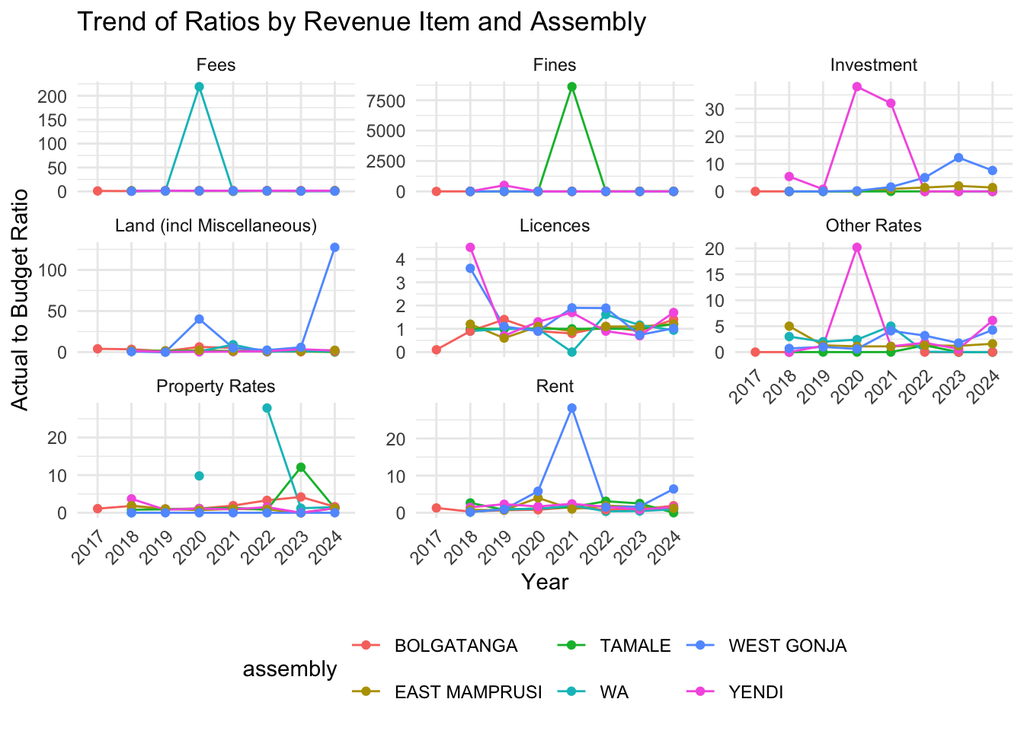

```
##  Box Plots: By Assembly
```

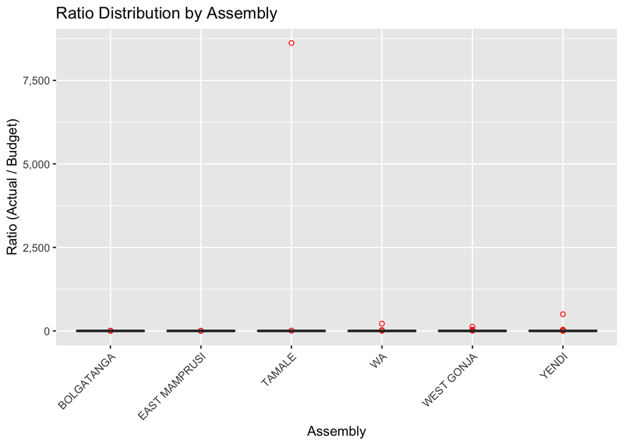

```
##  Box Plots: By Revenue Item ---
```

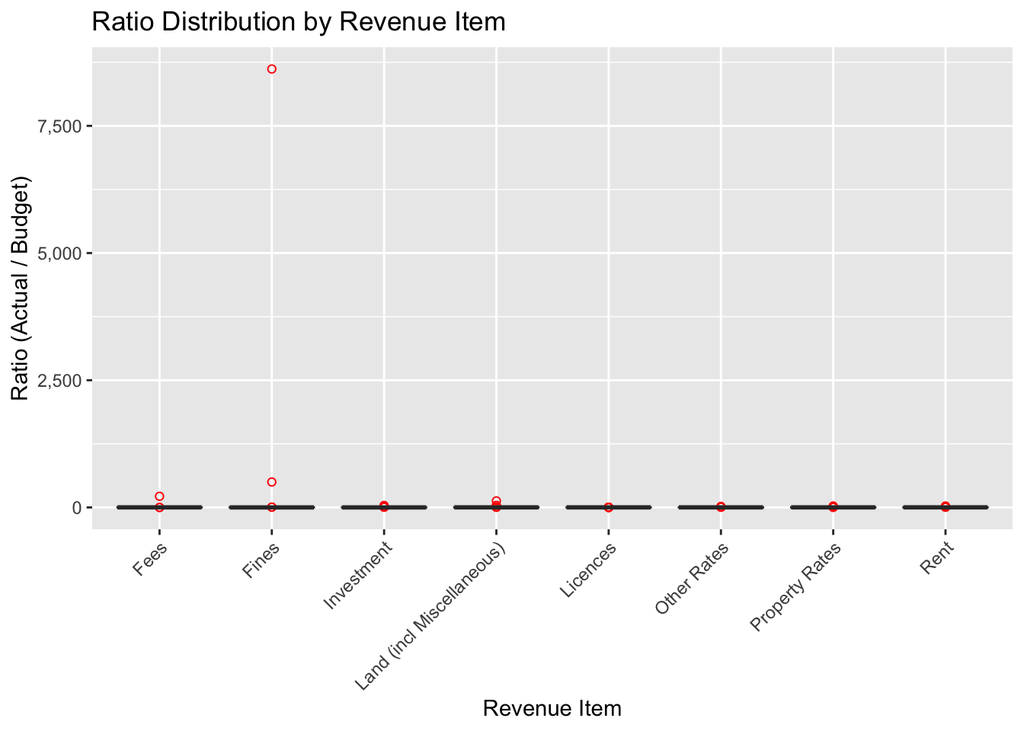

```
##  Box Plots: By Year ---
```

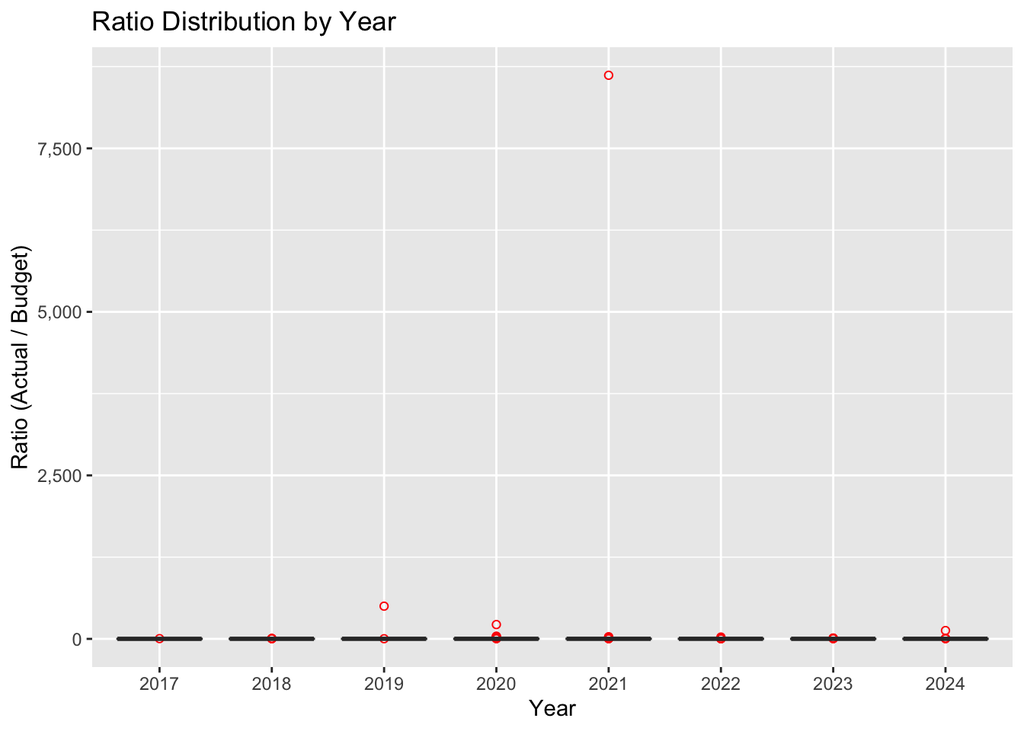

```
##  Line Plot: Mean Ratio by Assembly
```

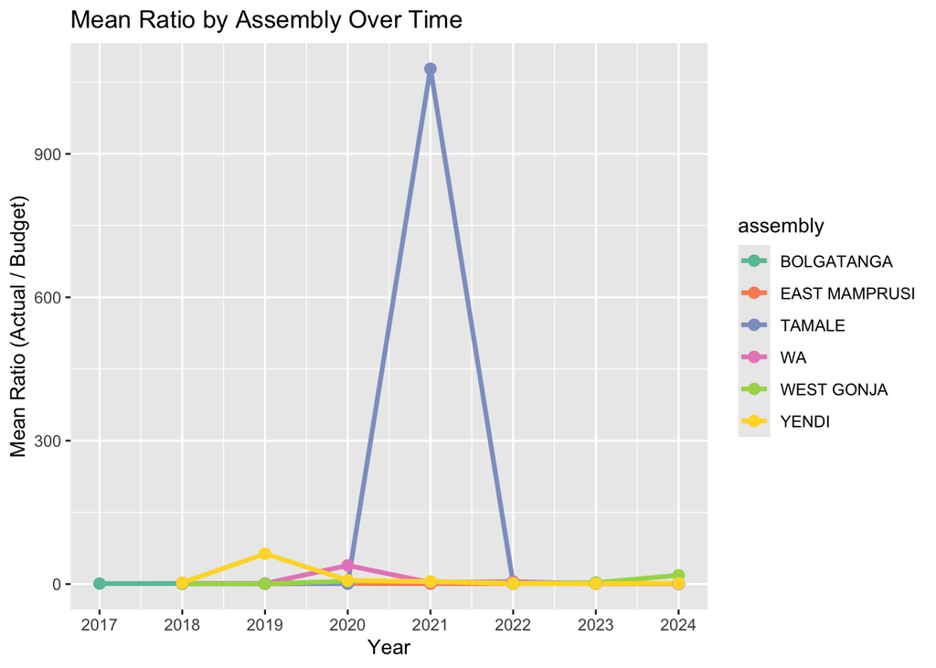

```
##  Line Plot: Median Ratio by Revenue Item
```

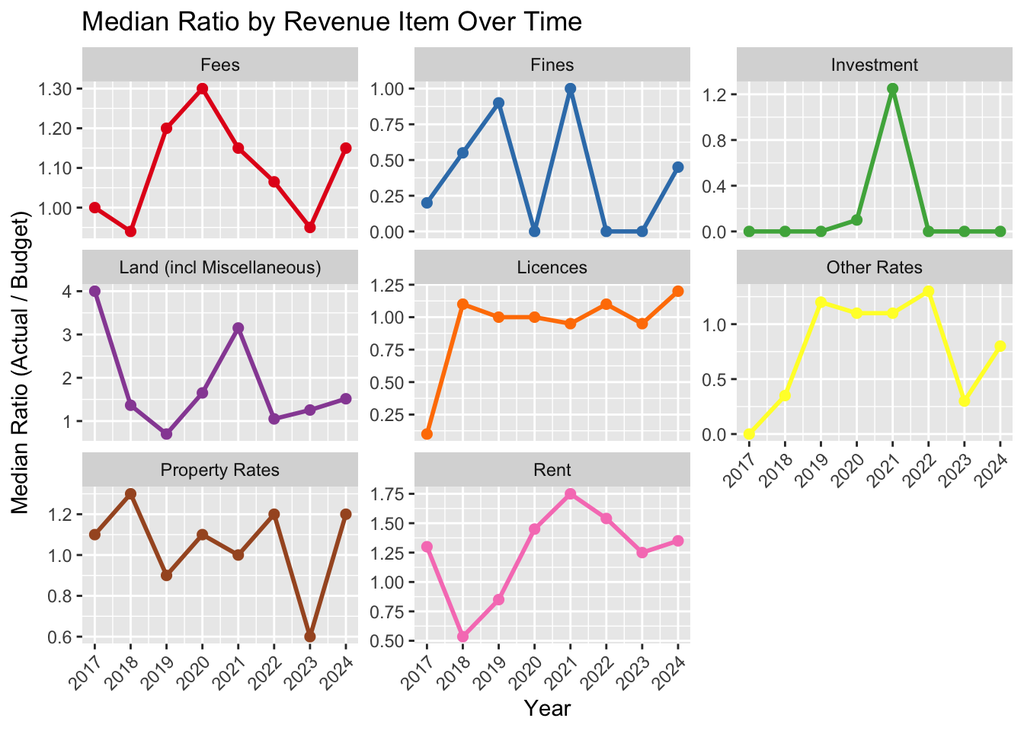

```
##  Heatmap: Assembly-Year ---
```

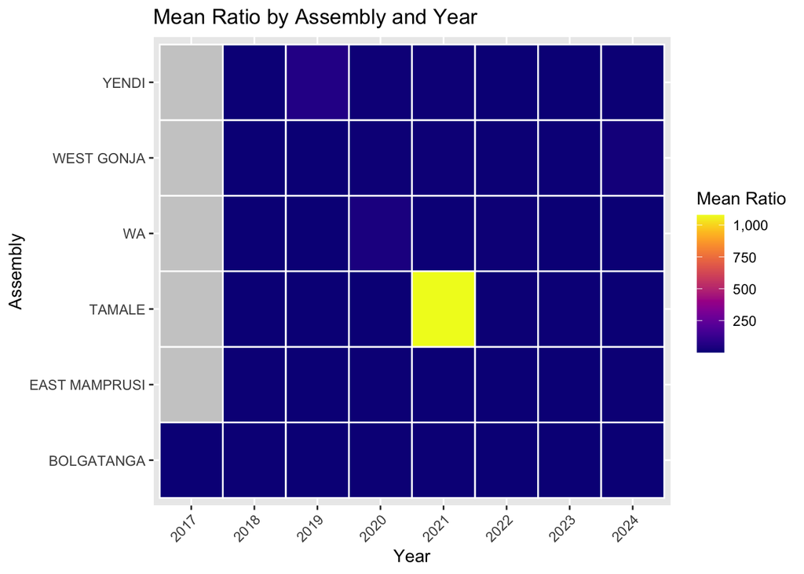

```
## -Bar Plot: Total Ratio by Assembly ---
```

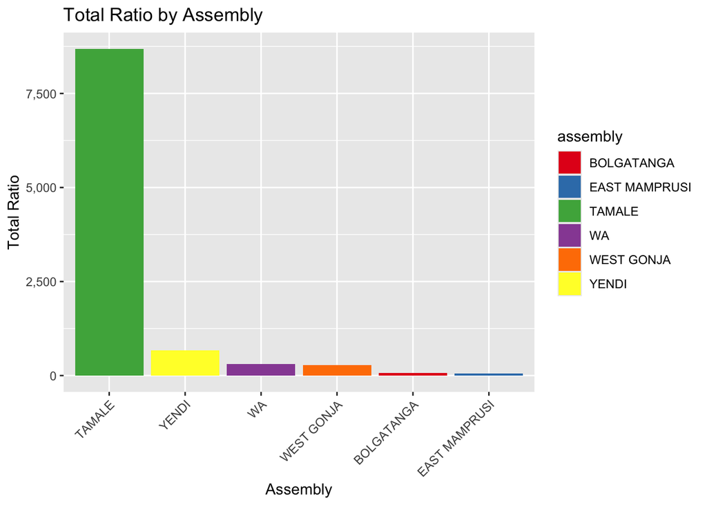

```
##  Bar Plot: Total Ratio by Revenue Item ---
```

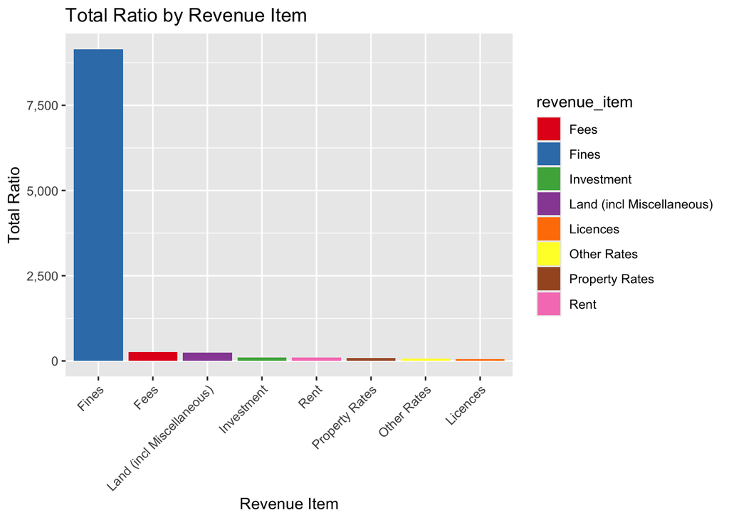

```
## Alluvial Plot: Revenue Item Share --
```

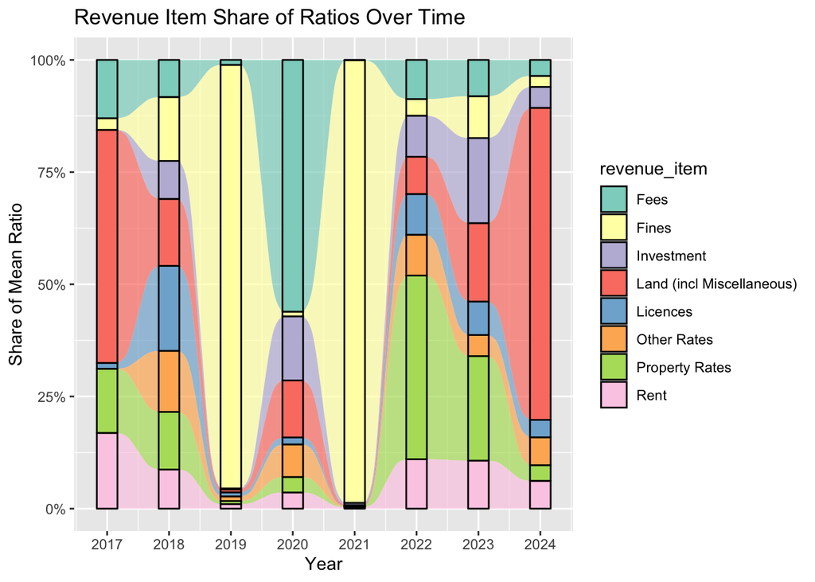

```
## --- Overall Distribution of Actual-to-Budget Ratio ---
```

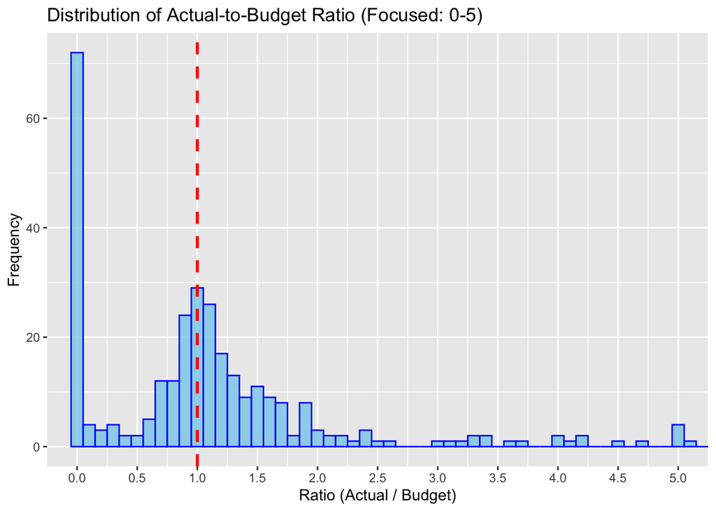

```
## --- Distribution of Actual-to-Budget Ratio by Year (Box Plots) ---
```

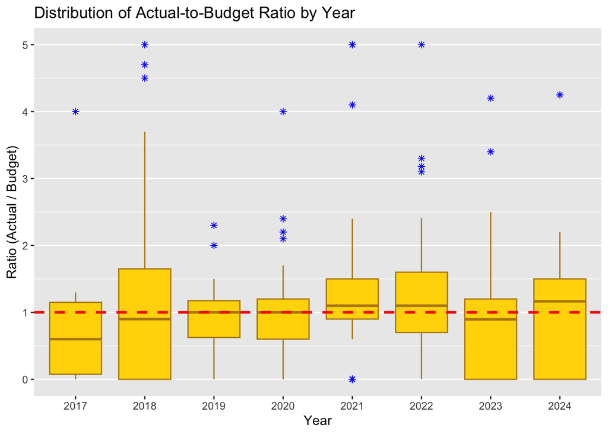

```
## Budget Performance by Assembly and Revenue Item (Median Ratios)
```

```
## Heatmap: Median Actual-to-Budget Ratio by Assembly and Year
```

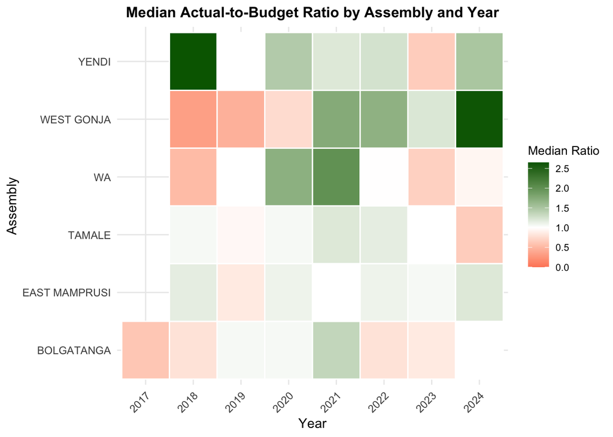

```
## Heatmap: Median Actual-to-Budget Ratio by Revenue Item and Year
```

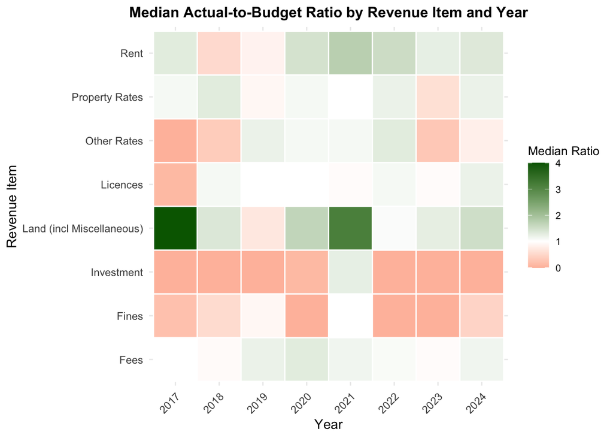

|  | assembly | revenue_item | year | Ratio_btn_Act_and_Bud | performance |
| --- | --- | --- | --- | --- | --- |
| 1 | TAMALE | Fines | 2021 | 8617.6 | Over-Performance |
| 2 | YENDI | Fines | 2019 | 500 | Over-Performance |
| 3 | WA | Fees | 2020 | 219 | Over-Performance |
| 4 | WEST GONJA | Land (incl Miscellaneous) | 2024 | 127.5 | Over-Performance |
| 5 | WEST GONJA | Land (incl Miscellaneous) | 2020 | 40.2 | Over-Performance |
| 6 | WA | Other Rates | 2022 | 0.06 | Under-Performance |
| 7 | TAMALE | Land (incl Miscellaneous) | 2024 | 0.1 | Under-Performance |
| 8 | BOLGATANGA | Licences | 2017 | 0.1 | Under-Performance |
| 9 | WA | Rent | 2018 | 0.15 | Under-Performance |
| 10 | BOLGATANGA | Fines | 2017 | 0.2 | Under-Performance |

|  | assembly | Fees | Fines | Investment | Land (incl Miscellaneous) | Licences | Other Rates | Property Rates | Rent |
| --- | --- | --- | --- | --- | --- | --- | --- | --- | --- |
| 1 | BOLGATANGA | 1.0625 | 1.1625 | 0 | 2.7625 | 0.9375 | 0 | 2 | 1.025 |
| 2 | EAST MAMPRUSI | 1.1 | 0 | 0.8142857142857143 | 1.528571428571429 | 1.028571428571429 | 1.8 | 0.9571428571428571 | 1.595714285714286 |
| 3 | TAMALE | 1.157142857142857 | 16.96128571428594 | 0 | 1.028571428571429 | 1.028571428571428 | 0.1857142857142857 | 2.6 | 1.678571428571429 |
| 4 | WA | 15.61557142857166 | 0.57 | 0 | 2.002857142857143 | 0.9457142857142857 | 1.778571428571429 | 8.068 | 0.8442857142857143 |
| 5 | WEST GONJA | 0.9185714285714286 | 0 | 3.804285714285714 | 22.56557142857166 | 1.592857142857143 | 2.224285714285714 | 0 | 6.385714285714285 |
| 6 | YENDI | 1.342857142857143 | 15.66128571428594 | 10.88571428571429 | 1.3 | 1.642857142857143 | 4.428571428571429 | 1.314285714285714 | 1.694285714285714 |

|  | year | revenue_item | median_ratio |
| --- | --- | --- | --- |
| 1 | 2017 | Fees | 1 |
| 2 | 2017 | Fines | 0.2 |
| 3 | 2017 | Investment | 0 |
| 4 | 2017 | Land (incl Miscellaneous) | 4 |
| 5 | 2017 | Licences | 0.1 |
| 6 | 2017 | Other Rates | 0 |
| 7 | 2017 | Property Rates | 1.1 |
| 8 | 2017 | Rent | 1.3 |
| 9 | 2018 | Fees | 0.9400000000000001 |
| 10 | 2018 | Fines | 0.55 |

[output cut: 54 more lines]

- Observations

Histogram (Overall Distribution): The histogram (binwidth = 0.1, range 0–5) shows a right-skewed distribution, with most ratios clustered around 0–2 (median = 1.0, Q1 = 0.34, Q3 = 1.6). A vertical line at ratio = 1 highlights frequent on-target performance. Extreme values ( 8,617.6) are excluded by the 0–5 focus , 23 rows beyond the range removed in box plots.

Most ratios are near 1 (actual ≈ budgeted), but extreme over-performances (e.g., Tamale’s Fines) drive skewness, confirming descriptive stats (skewness = 17.92, kurtosis = 323.24).

Assembly Performance: Tamale Leads, East Mamprusi Lags: Box Plots (Assembly): Tamale’s box plot shows a wide range with outliers ( 8,617.6), a median of 1.0, and high variability (SD = 1,151.41). Yendi and WA have medians of 1.3 and 1.0, with up to 500 and 219. East Mamprusi and Bolgatanga have tight ranges (medians 1.1, 0.95; max 5.0, 6.3), indicating low variability.

Comparison: Tamale’s dominance mirrors diff_btw_Act_and_Bud (mean = 56,921, median = 8,543) and contribution_to_rev (median = 9.95%). East Mamprusi’s lag aligns with its low diff_btw_Act_and_Bud (mean = 3,052) and contribution_to_rev (median = 6.35%).

Revenue Items: Fines Volatile, Land/Fees Reliable:

Box Plots (Revenue Item): Fines have a median of 0.0 (42% zeros), (max = 8,617.6). Land and Fees have medians of 1.13 and 1.10, with up to 127.5 and 219. Licences show the tightest range (median = 1.0, max = 4.5), while Investment has many zeros (48%, median = 0.0).

Fines’ volatility (median = 0.0, max = 8,617.6) reflects inconsistent collection, while Land and Fees are reliable (medians 1.1–1.13). Licences’ stability contrasts with contribution_to_rev’s high contribution (median = 35%). Investment’s zeros (48%) align with its diff_btw_Act_and_Bud deficits (mean = -1,172).

Temporal Trends: 2021 Peak, 2017 Low:

Line Plot (Mean Ratio by Assembly): 2021 shows a sharp peak (Tamale 1,077.98), with 2019 secondary (Yendi ~63.42). 2017 is flat (0.96).

2021’s peak (Fines, Tamale) and 2019’s secondary spike (Fines, Yendi) drive temporal variance, while 2024’s broad overperformance (median = 1.2) suggests improvement.

```
## --- Kruskal-Wallis Test: Assembly ---
```

Kruskal-Wallis Test: Ratio by Assembly

| Test | Chi_Squared | P_Value |
| --- | --- | --- |
| Kruskal-Wallis (Assembly) | 4.04 | 0.544 |

```
## --- Kruskal-Wallis Test: Revenue Item ---
```

Kruskal-Wallis Test: Ratio by Revenue Item

| Test | Chi_Squared | P_Value |
| --- | --- | --- |
| Kruskal-Wallis (Revenue Item) | 29.313 | 0 |

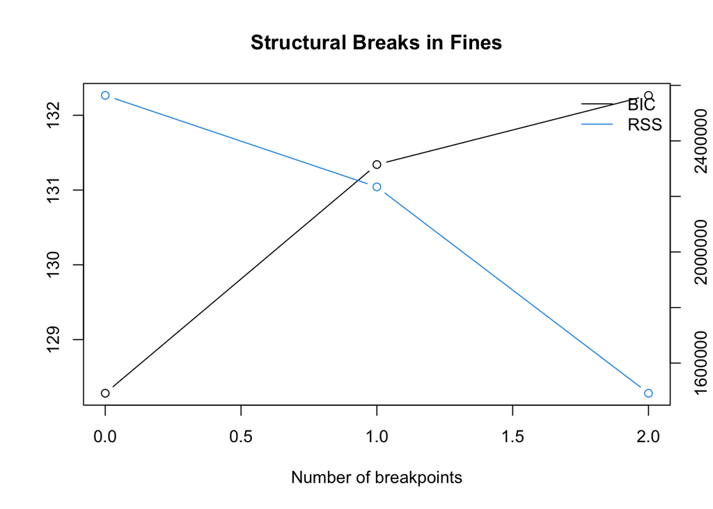

```
##
##   Optimal (m+1)-segment partition:
##
## Call:
## breakpoints.formula(formula = mean_ratio ~ 1, h = 0.3, data = breakpoint_data)
##
## Breakpoints at observation number:
##
## m = 1   4
## m = 2   3 5
##
## Corresponding to breakdates:
##
## m = 1   0.5
## m = 2   0.375 0.625
##
## Fit:
##
## m   0         1         2
## RSS 2563779.4 2234296.2 1491392.8
## BIC     128.3     131.3     132.3
```

- Observations

Kruskal-Wallis Test (Assembly): The test yields a chi-squared statistic of 4.04 with a p-value of 0.544, indicating no significant differences in Ratio_btn_Act_and_Bud across the 6 assemblies (WA, Tamale, Bolgatanga, Yendi, East Mamprusi, West Gonja).

Despite Tamale’s high mean ratio (155.11, driven by values like 8,617.6) and East Mamprusi’s low mean (1.10), the non-significant result suggests that assembly differences are not consistent across all data points. High skewness (17.92) and outliers likely mask differences in medians (0.95–1.30). The test’s non-parametric nature accounts for non-normality, but variability ( Tamale’s SD = 1,151.41) reduces statistical power.

Kruskal-Wallis Test (Revenue Item): The test yields a chi-squared statistic of 29.313 with a p-value < 0.001, indicating significant differences in Ratio_btn_Act_and_Bud across the 8 revenue items (Property Rates, Other Rates, Fees, Fines, Licences, Land, Rent, Investment).

The significant result confirms that revenue items perform differently, with Fines having the highest mean (234.59, max = 8,617.6) but a median of 0.0 (42% zeros), and Land/Fees showing reliable medians (1.13, 1.10). Licences are stable but low (median = 1.0, max = 4.5), while Investment has many zeros (48%).

Two Breakpoints: At observations 3 and 5 (2019–2020 and 2021–2022, breakdates 0.375 and 0.625), with RSS = 1,491,392.8 and BIC = 132.3.

# Conclusion

Budgeting Performance is Generally On-Target:

The median ratio of 1.0 across assemblies, revenue items, and years indicates that actual revenue often matches budgeted revenue, suggesting effective budgeting in most cases. However, extreme outliers like ( 8,617.6 for Tamale’s 2021 Fines, 500 for Yendi’s 2019 Fines) inflate the mean (30.72) and skewness (17.92), highlighting rare but significant overperformances. Visualizations ( histogram, box plots) confirm most ratios cluster around 0–2, with outliers driving variability ( Tamale’s SD = 1,151.41).

Significant Revenue Item Disparities, with Fines Volatile and Land/Fees Reliable:

The Kruskal-Wallis test for revenue items (chi-squared = 29.313, p < 0.001) confirms significant differences, with Fines showing the highest mean (234.59) but a median of 0.0 (42% zeros). Land (mean = 5.69, median = 1.13) and Fees (6.15, 1.10) are reliable, with fewer zeros (2–1) and moderate outliers (max 127.5, 219). Licences are stable but low (median = 1.0, max = 4.5), while Investment has frequent zeros (48%). Visualizations ( box plots, heatmaps) highlight Fines’ volatility (2021 peak) and Land/Fees’ consistency (2024/2020 peaks).

No Significant Assembly Differences, but Tamale Leads Practically:

Implication: Uniform budgeting approaches are suitable, but Tamale’s strategies ( Fines enforcement) can guide underperforming assemblies like East Mamprusi. This aligns with diff_btw_Act_and_Bud’s non-significant assembly test (p = 0.144) and contribution_to_rev’s (p = 0.923), where Tamale also leads practically.

Temporal Peaks in 2021 and 2019, with 2017 Data Gaps:

Strategic Recommendations

Budgeting: Focus budgets on Land and Fees for reliable revenue, addressing Fines’ volatility and Investment’s non-collection.

Regional: Replicate Tamale’s enforcement strategies in East Mamprusi/Bolgatanga, where low ratios persist, to boost performance.